# DoD Fixed-Price Study

Greg Sanders

Tuesday, January 13, 2015

Contracts are classified using a mix of numerical and categorical variables. While the changes in numerical variables are easy to grasp and summarize, the move from being a research and development (R&D) contract and the like to a product contract requires deliberate consideration. As an important added factor, for the fixed-price study, we are only considering information that contracting officer knew going in. This is an attempt to avoid having our independent variables influenced by contract performance. For example, a standard of 50% R&D content by value would be influenced by whether the R&D portion of the project took longer than expected.

## Studying R&D contracts in the sample.

```
##   isAnyRnD1to5    obligatedAmountRnD1to5 firstSignedDateRnD1to5
##  Min.   :0.0000   Min.   :-9.541e+06     Length:15000
##  1st Qu.:0.0000   1st Qu.: 1.935e+06     Class :character
##  Median :0.0000   Median : 1.021e+07     Mode  :character
##  Mean   :0.0858   Mean   : 9.601e+07
##  3rd Qu.:0.0000   3rd Qu.: 4.419e+07
##  Max.   :1.0000   Max.   : 1.314e+10
##  NA's   :414      NA's   :13748
```

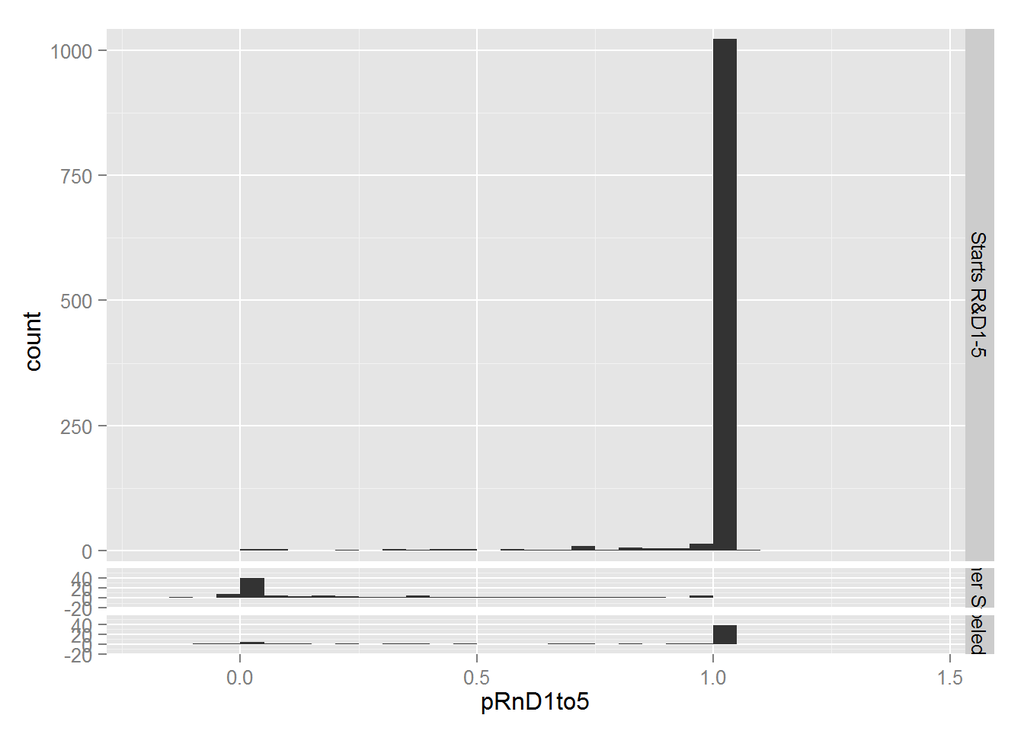

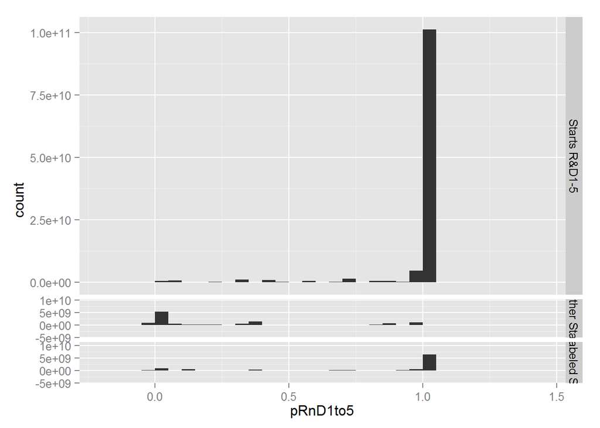

Based on this first analysis, it appears that labeling an R&D(1-5) contract by its first element asctually works for at least 90% of cases.

- The biggest problem appears to be those contracts whose first entry is not labeled. However, the vast majority of those contracts are 95%-100% R&D(1-5), which should make classifying them fairly easy.
- Those contracts that start as non-R&D are consistently below 50% R&D(1-5) with a noteable exception in the 95% to 100% range. Capturing those should be simple.
- Those contracts that start R&D(1-5) but have less than 50% of dollars in that category might be false positives.

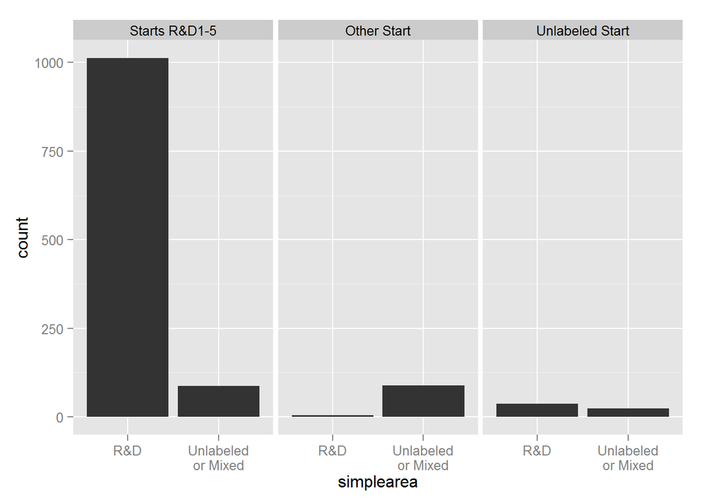

[figure not shown]

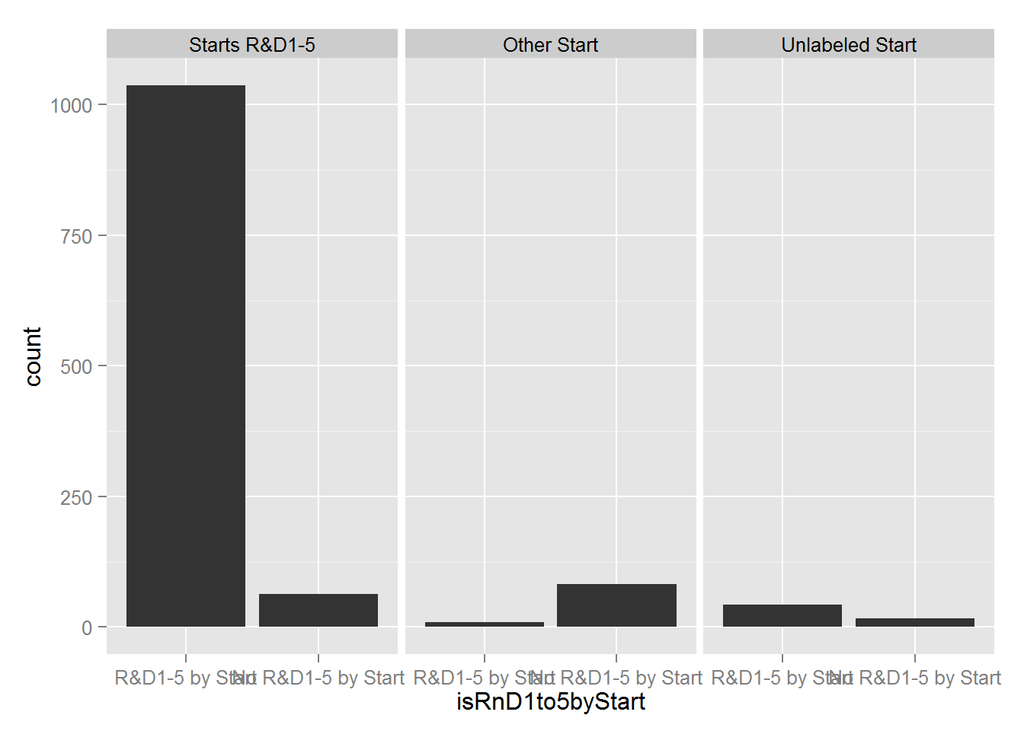

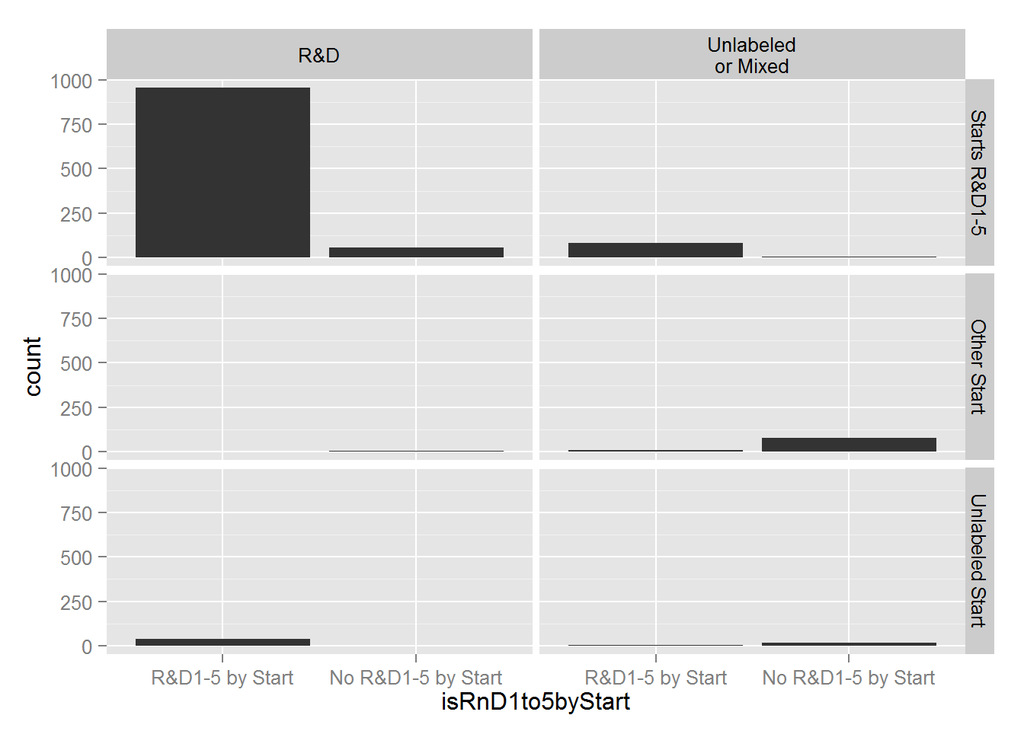

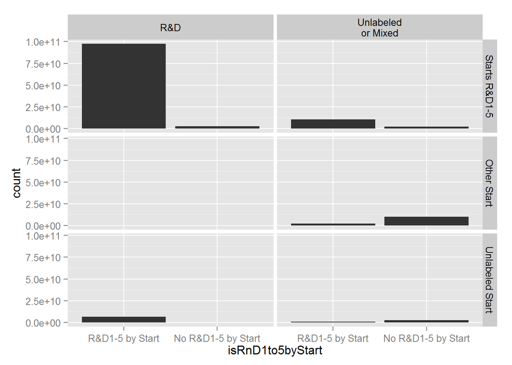